# Pwani University Boot Camp

Author : Moses Kioko

Date : November 28, 2020

# 1 Work space set up

Prior to scripting in R, we removing the objects in R memory to pave way for a new objects, we do this by help of `rm()` function.

```r
#clear objects
rm(list = ls(all=T))
```

For easier access of files in directory and organized saving objects in R memory we need to change default computer directory to a folder that we can easily trace and access. We do this my help of `setwd()` function.

```r
#setting working directory

#set working directory
setwd('D:/pwani data collection/eric/Revised Bootcamp/MAWW/Workshop')

# print the current working directory
print(getwd())
```

```
## [1] "D:/pwani data collection/eric/Revised Bootcamp/MAWW/Workshop"
```

# 2 Packages

Installing packages can be done by downloading the packages from CRAN repository to R environment.*Please note; if you had prior installation of this packages you can skip re-installing them*

## 2.1 Installing Packages

- Installing packages from CRAN
  - install single package *i.e* `install.package("lubridate")`
  - install multiple packages by use of concatenator **c** *i,e* `install.packages(c('tidyverse','lubridate','forecast'))`
- Installing Packages from Github
  - install devtools package *i.e* `install.packages("devtools")`
  - load the library *i.e* `library(devtools)`
  - install the package *i.e* `devtools::install_github("tidyverse/lubridate")`

```r
#installing packages
#install.packages(c('tidyverse','lubridate','janitor','viridis','forecast'), dependencies = TRUE)
```

Attached is a brief description of the packages that will be used in this session

| Package | Description |
| --- | --- |
| Tidyverse Package | Manipulating data and plotting data [link](https://tidyverse.tidyverse.org/) |
| Lubridate package | Manipulating and changing date format [link](https://www.rdocumentation.org/packages/lubridate) |
| Janitor Package | Cleaning column names [link](https://www.rdocumentation.org/packages/janitor/versions/2.0.1) |
| Viridis Package | R color scale [link](https://www.rdocumentation.org/packages/viridis/versions/0.5.1) |
| Forecast Package | Handy in time-series [link](https://www.rdocumentation.org/packages/forecast/versions/8.13/topics/Arima) |

## 2.2 Loading Packages

To use the functions in a package you should load the package into R memory and you can do that by ;

- loading single package *i.e* `library()` command
- Load multiple packages *i.e* [pacman package](https://www.rdocumentation.org/packages/pacman/versions/0.5.1)

```r
#load libraries
library(tidyverse) # manipulating data, plotting package
library(lubridate) # changing date formats
library(janitor) # cleaning variable names
library(viridis) # coloring package
library(forecast) # for time series
```

# 3 Importing Data

Reading data into R memory using [readr package](https://www.rdocumentation.org/packages/readr/versions/1.3.1) housed in tidyverse package

```r
#import temperature data
temp <- read_delim('temperature.csv',';',trim_ws = TRUE) %>%
  clean_names()

#import precipitation data
precipitation <- read_delim('precipitation.csv', ';',trim_ws = TRUE) %>%
  clean_names()

#import MAWM data
yield <- read_delim('MAWW_data.csv',';',trim_ws = TRUE) %>%
  clean_names()
```

# 4 Temperature Data

The are several steps that are involved to clean the temperature data ;

- Change the date format using lubricate package
- Calculate the year from date
- Summarize the mean temperature per year and site

```r
#summarizing data
temp_per_site <- temp %>%
  mutate(date = as_date(exceldate,origin ="1899-01-01")) %>%
  mutate(year = year(date)) %>%
  group_by(site,year) %>%
  summarise(mean_temp = mean(value)) %>%
    dplyr::filter(year<2006)
```

## 4.1 Scatter Graph (loess fit)

To under understand general distribution of mean annual temperature we do a scatter plot with polynomial fit fuction

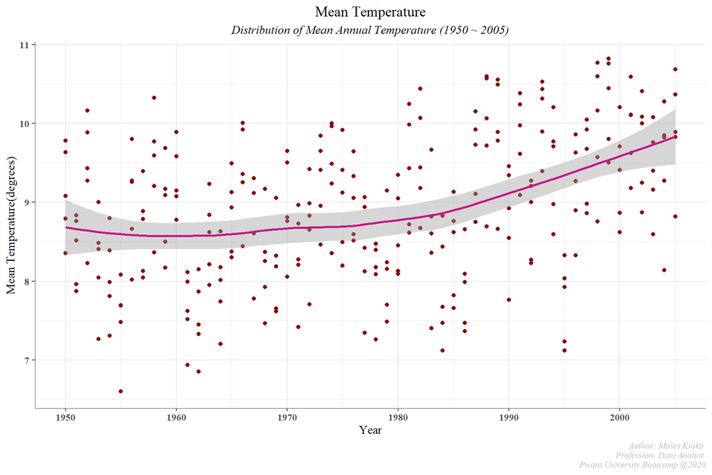

```r
#Single plot the data
loess_temp <- temp_per_site %>%
  ggplot(aes(year,mean_temp))+
  geom_point(color ='#8A0707')+
  geom_smooth(stat = 'smooth',method = 'loess',color ='#c71585')+
  theme_minimal()+
  labs(title = "Mean Temperature",
       subtitle = "Distribution of Mean Annual Temperature (1950 ~ 2005)",
       y="Mean Temperature(degrees)",
       x="Year",
       caption = 'Author: Moses Kioko \n Profession: Data Analyst \n Pwani University Bootcamp @2020')+
  theme(legend.position = "bottom",
        legend.background = element_rect(color = "grey"),
        legend.title =  element_blank(),
        legend.text = element_text(family = "serif"),
        plot.title = element_text(hjust = 0.5,family = "serif"),
        axis.text = element_text(family = "serif", face = 'bold'),
        axis.title = element_text(family = "serif"),
        axis.line = element_line(colour = "grey30",size = .2),
        axis.ticks = element_line(colour = "grey30"),
        plot.subtitle = element_text(family = "serif",face = "italic",hjust = 0.5),
        plot.caption = element_text(size = 8,color = "grey",family = "serif",face = 'italic'))


#save the plot
ggsave(plot= loess_temp,
       height = 8.1,
       width = 12,
       dpi = 1000,
       device = 'jpg',
       filename = 'Mean Annual Temperature Distribution Trend.jpg')

#print the plot
print(loess_temp)
```

## 4.2 Scatter Graph (linear fit)

To under understand trend of mean annual temperature distribution we do a scatter plot with linear fit function

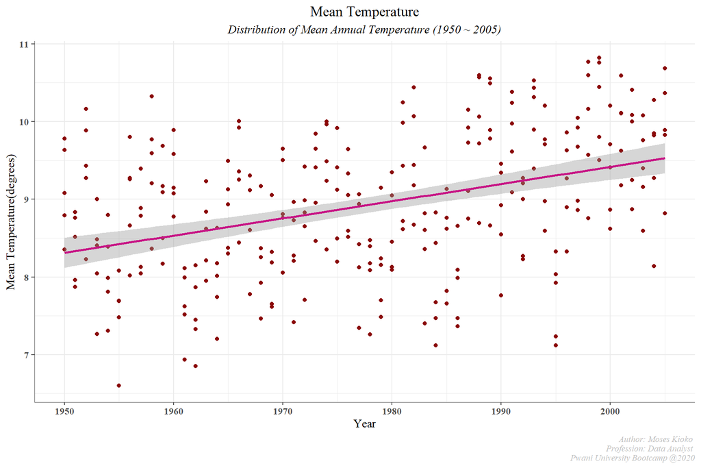

```r
#Single plot the data
# please exclude the anything above 2006
lm_temp <- temp_per_site %>%
  ggplot(aes(year,mean_temp))+
  geom_point(color ='#8A0707')+
  geom_smooth(stat = 'smooth',method = 'lm',color ='#c71585')+
  theme_minimal()+
  labs(title = "Mean Temperature",
       subtitle = "Distribution of Mean Annual Temperature (1950 ~ 2005)",
       y="Mean Temperature(degrees)",
       x="Year",
       caption = 'Author: Moses Kioko \n Profession: Data Analyst \n Pwani University Bootcamp @2020')+
  theme(legend.position = "bottom",
        legend.background = element_rect(color = "grey"),
        legend.title =  element_blank(),
        legend.text = element_text(family = "serif"),
        plot.title = element_text(hjust = 0.5,family = "serif"),
        axis.text = element_text(family = "serif", face = 'bold'),
        axis.title = element_text(family = "serif"),
        axis.line = element_line(colour = "grey30",size = .2),
        axis.ticks = element_line(colour = "grey30"),
        plot.subtitle = element_text(family = "serif",face = "italic",hjust = 0.5),
        plot.caption = element_text(size = 8,color = "grey",family = "serif",face = 'italic'))


#save the plot
ggsave(plot= lm_temp,
       height = 8.1,
       width = 12,
       dpi = 1000,
       device = 'jpg',
       filename = 'Mean Annual Temperature Distribution Linear Regression plot.jpg')

#print the plot
print(lm_temp)
```

## 4.3 Box Plot

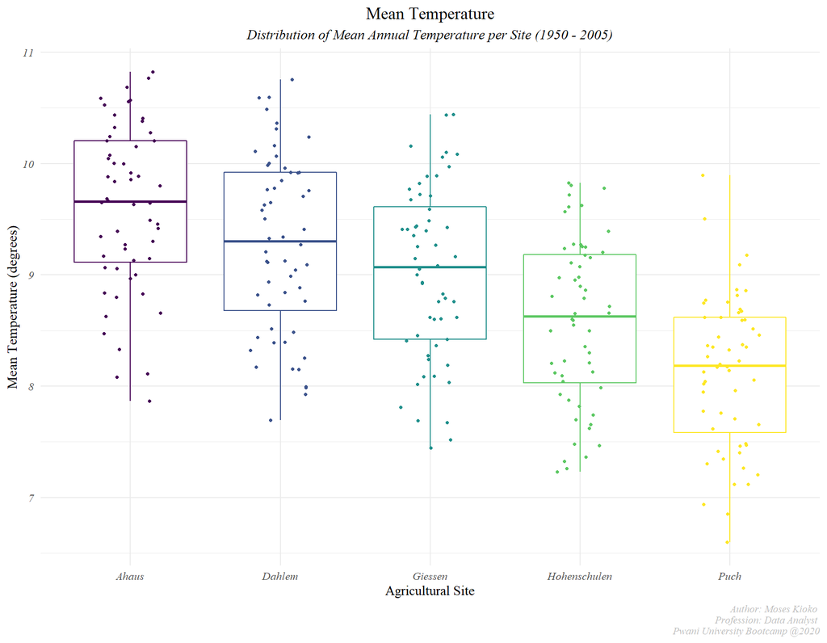

```r
#distribution of temperature per site
box_temp <- temp_per_site %>%
  ggplot(aes(site,mean_temp,color =site))+
  geom_boxplot(outlier.shape = 18,
               outlier.colour = "red",
               outlier.alpha = 1,
               outlier.size = 2.5)+
  geom_jitter(shape=16, position=position_jitter(0.2),cex=0.9)+
  scale_color_viridis_d()+
  theme_minimal()+
  labs(title = "Mean Temperature",
       subtitle = "Distribution of Mean Annual Temperature per Site (1950 - 2005)",
       y="Mean Temperature (degrees)",
       x="Agricultural Site",
       caption = 'Author: Moses Kioko \n Profession: Data Analyst \n Pwani University Bootcamp @2020')+
  theme(legend.position = "none",
        legend.background = element_rect(color = "grey"),
        legend.title =  element_blank(),
        legend.text = element_text(family = "serif"),
        plot.title = element_text(hjust = 0.5,family = "serif"),
        axis.text = element_text(family = "serif", face = 'italic'),
        axis.title = element_text(family = "serif"),
        plot.subtitle = element_text(family = "serif",face = "italic",hjust = 0.5),
        plot.caption = element_text(size = 8,color = "grey",family = "serif",face = 'italic'))



#save the plot
ggsave(plot= box_temp,
       height = 8.1,
       width = 12,
       dpi = 1000,
       device = 'jpg',
       filename = 'Mean Annual Temperature Distribution boxplot plot.jpg')


#plot the graph
print(box_temp)
```

## 4.4 Bar Graph

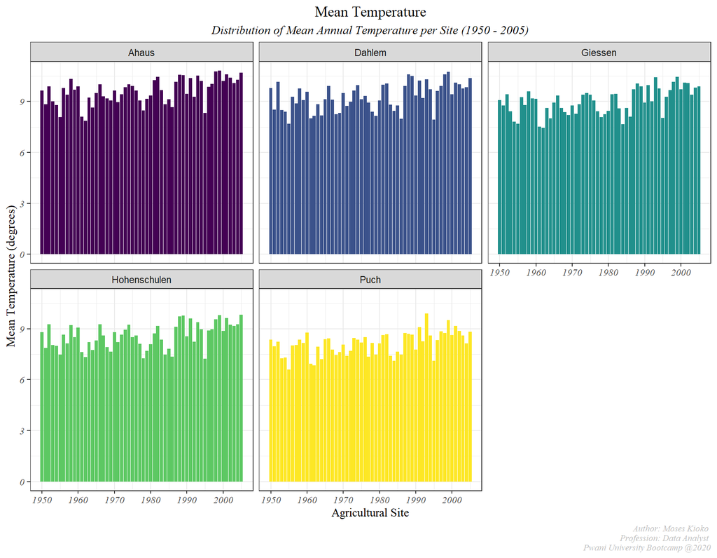

```r
#distribution of temperature per site
temp_bar_graph <- temp_per_site %>%
  ggplot(aes(year,mean_temp,fill =site))+
  geom_col(position = 'dodge')+
  facet_wrap(~site)+
  scale_fill_viridis_d()+
  theme_bw()+
  labs(title = "Mean Temperature",
       subtitle = "Distribution of Mean Annual Temperature per Site (1950 - 2005)",
       y="Mean Temperature (degrees)",
       x="Agricultural Site",
       caption = 'Author: Moses Kioko \n Profession: Data Analyst \n Pwani University Bootcamp @2020')+
  theme(legend.position = "none",
        legend.background = element_rect(color = "grey"),
        legend.title =  element_blank(),
        legend.text = element_text(family = "serif"),
        plot.title = element_text(hjust = 0.5,family = "serif"),
        axis.text = element_text(family = "serif", face = 'italic'),
        axis.title = element_text(family = "serif"),
        plot.subtitle = element_text(family = "serif",face = "italic",hjust = 0.5),
        plot.caption = element_text(size = 8,color = "grey",family = "serif",face = 'italic'))



#save the plot
ggsave(plot= temp_bar_graph,
       height = 8.1,
       width = 12,
       dpi = 1000,
       device = 'jpg',
       filename = 'Mean Annual Temperature Distribution bar graph.jpg')

#plot the graph
print(temp_bar_graph)
```

# 5 Precipitation Data

The following steps are used to tidy the precipitation data;

- Change the date format using lubricate package
- Calculate the year from date
- Summarize the mean precipitation per year and site

```r
#cleaning precipitation data by formatting date and calculating mean precipitation per year and site
precip_per_site <- precipitation %>%
  mutate(date = as_date(exceldate,origin ="1899-01-01")) %>%
  mutate(year = year(date)) %>%
  group_by(site,year) %>%
  summarise(mean_precip = mean(value)) %>%
  clean_names() %>%
  dplyr::filter(year<2006)
```

## 5.1 Scatter Plot (loess fit)

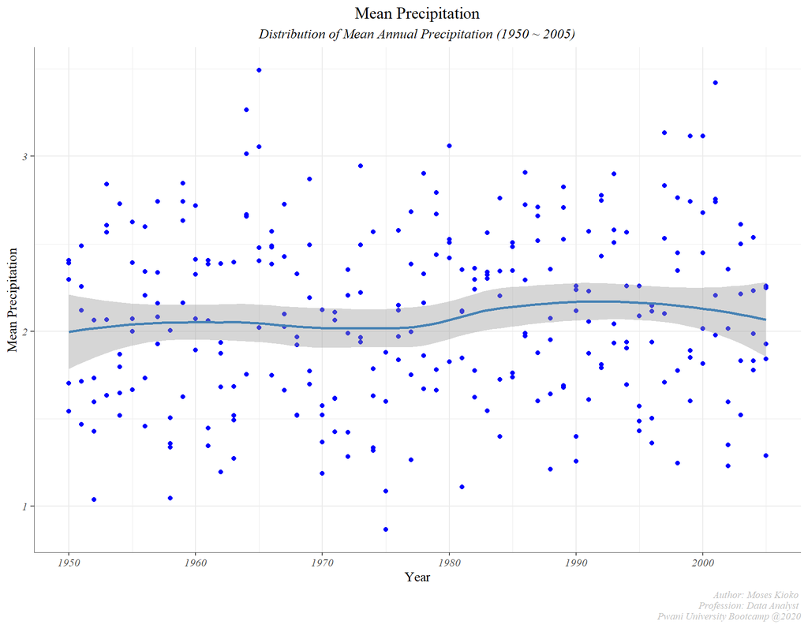

```r
#Single plot the data
prep_polynominal <- precip_per_site %>%
  ggplot(aes(year,mean_precip))+
  geom_point(color ='blue')+
  geom_smooth(stat = 'smooth',method = 'loess',color ='steelblue')+
  theme_minimal()+
  labs(title = "Mean Precipitation",
       subtitle = "Distribution of Mean Annual Precipitation (1950 ~ 2005)",
       y="Mean Precipitation",
       x="Year",
       caption = 'Author: Moses Kioko \n Profession: Data Analyst \n Pwani University Bootcamp @2020')+
  theme(legend.position = "bottom",
        legend.background = element_rect(color = "grey"),
        legend.title =  element_blank(),
        legend.text = element_text(family = "serif"),
        plot.title = element_text(hjust = 0.5,family = "serif"),
        axis.text = element_text(family = "serif", face = 'italic'),
        axis.title = element_text(family = "serif"),
        axis.line = element_line(colour = "grey30",size = .2),
        axis.ticks = element_line(colour = "grey30"),
        plot.subtitle = element_text(family = "serif",face = "italic",hjust = 0.5),
        plot.caption = element_text(size = 8,color = "grey",family = "serif",face = 'italic'))



#save the plot
ggsave(plot= prep_polynominal,
       height = 8.1,
       width = 12,
       dpi = 1000,
       device = 'jpg',
       filename = 'Mean Annual Precipitation Distribution polynomial fit graph.jpg')

#plot the graph
print(prep_polynominal)
```

## 5.2 Scatter plot (Linear fit)

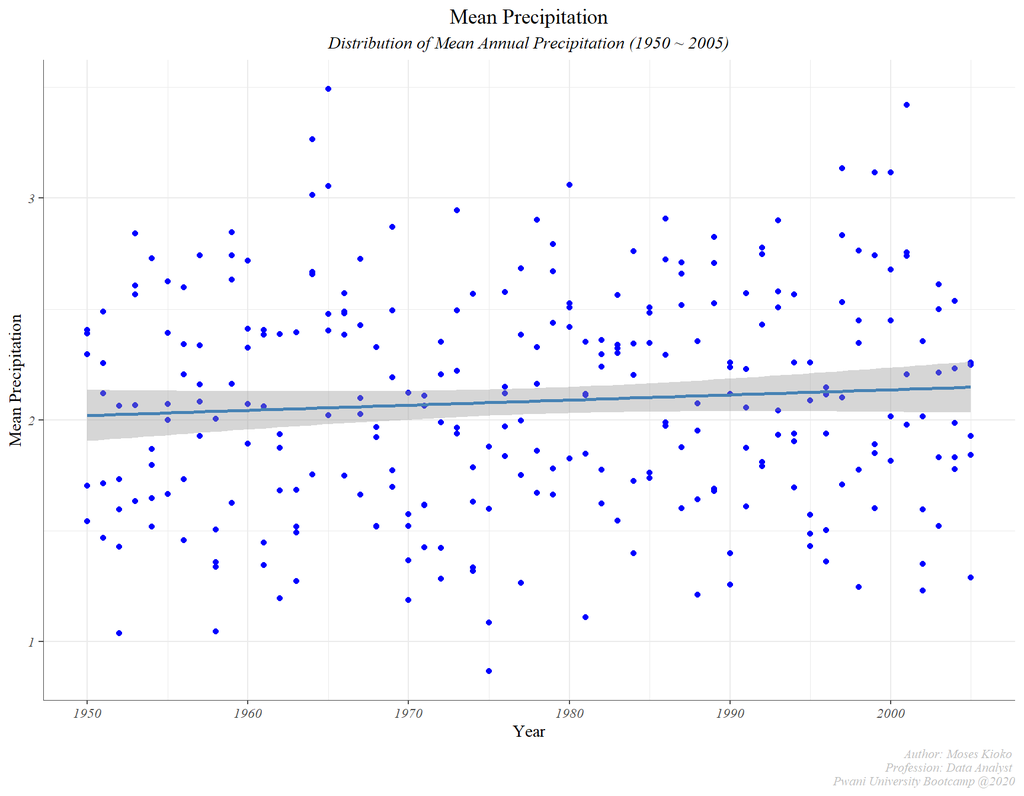

```r
#Single plot the data
prep_linear <- precip_per_site %>%
  ggplot(aes(year,mean_precip))+
  geom_point(color ='blue')+
  geom_smooth(stat = 'smooth',method = 'lm',color ='steelblue')+
  theme_minimal()+
  labs(title = "Mean Precipitation",
       subtitle = "Distribution of Mean Annual Precipitation (1950 ~ 2005)",
       y="Mean Precipitation",
       x="Year",
       caption = 'Author: Moses Kioko \n Profession: Data Analyst \n Pwani University Bootcamp @2020')+
  theme(legend.position = "bottom",
        legend.background = element_rect(color = "grey"),
        legend.title =  element_blank(),
        legend.text = element_text(family = "serif"),
        plot.title = element_text(hjust = 0.5,family = "serif"),
        axis.text = element_text(family = "serif", face = 'italic'),
        axis.title = element_text(family = "serif"),
        axis.line = element_line(colour = "grey30",size = .2),
        axis.ticks = element_line(colour = "grey30"),
        plot.subtitle = element_text(family = "serif",face = "italic",hjust = 0.5),
        plot.caption = element_text(size = 8,color = "grey",family = "serif",face = 'italic'))



#save the plot
ggsave(plot= prep_linear,
       height = 8.1,
       width = 12,
       dpi = 1000,
       device = 'jpg',
       filename = 'Mean Annual Precipitation Distribution Linear fit graph.jpg')

#plot the graph
print(prep_linear)
```

## 5.3 Box Plot

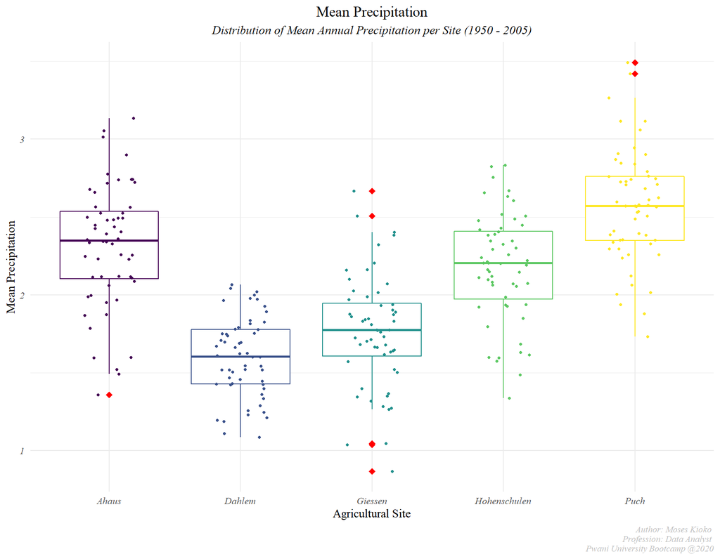

```r
#distribution of precipitation per site
scatter_boxplot_prep <- precip_per_site %>%
  ggplot(aes(site,mean_precip,color =site))+
  geom_boxplot(outlier.shape = 18,
               outlier.colour = "red",
               outlier.alpha = 1,
               outlier.size = 2.5)+
  geom_jitter(shape=16, position=position_jitter(0.2),cex=0.9)+
  scale_color_viridis_d()+
  theme_minimal()+
  labs(title = "Mean Precipitation",
       subtitle = "Distribution of Mean Annual Precipitation per Site (1950 - 2005)",
       y="Mean Precipitation",
       x="Agricultural Site",
       caption = 'Author: Moses Kioko \n Profession: Data Analyst \n Pwani University Bootcamp @2020')+
  theme(legend.position = "none",
        legend.background = element_rect(color = "grey"),
        legend.title =  element_blank(),
        legend.text = element_text(family = "serif"),
        plot.title = element_text(hjust = 0.5,family = "serif"),
        axis.text = element_text(family = "serif", face = 'italic'),
        axis.title = element_text(family = "serif"),
        plot.subtitle = element_text(family = "serif",face = "italic",hjust = 0.5),
        plot.caption = element_text(size = 8,color = "grey",family = "serif",face = 'italic'))


#save the plot
ggsave(plot= scatter_boxplot_prep,
       height = 8.1,
       width = 12,
       dpi = 1000,
       device = 'jpg',
       filename = 'Mean Annual Precipitation Distribution box plot.jpg')

#plot the graph
print(scatter_boxplot_prep)
```

## 5.4 Bar Graph

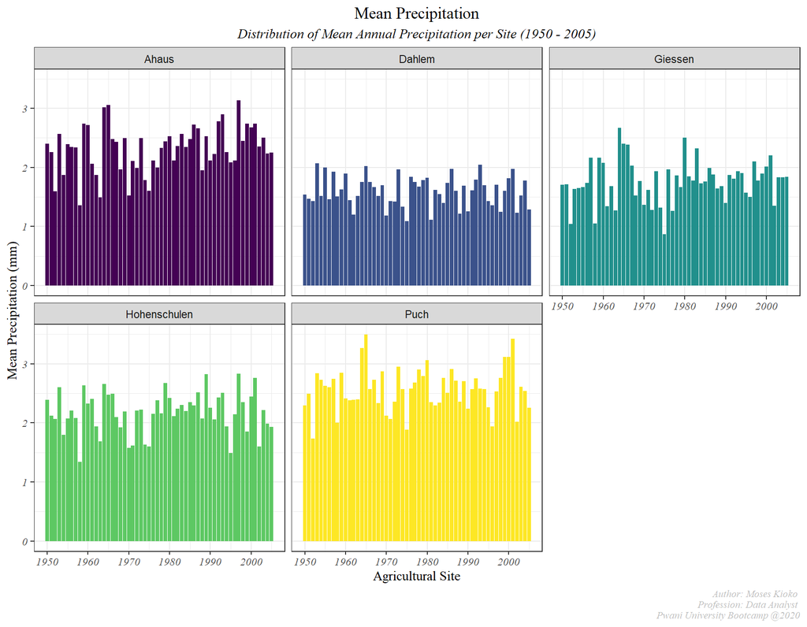

```r
#distribution of precipitation per site
prep_bar <- precip_per_site %>%
  ggplot(aes(year,mean_precip,fill =site))+
  geom_col(position = 'dodge')+
  facet_wrap(~site)+
  scale_fill_viridis_d()+
  theme_bw()+
  labs(title = "Mean Precipitation",
       subtitle = "Distribution of Mean Annual Precipitation per Site (1950 - 2005)",
       y="Mean Precipitation (mm)",
       x="Agricultural Site",
       caption = 'Author: Moses Kioko \n Profession: Data Analyst \n Pwani University Bootcamp @2020')+
  theme(legend.position = "none",
        legend.background = element_rect(color = "grey"),
        legend.title =  element_blank(),
        legend.text = element_text(family = "serif"),
        plot.title = element_text(hjust = 0.5,family = "serif"),
        axis.text = element_text(family = "serif", face = 'italic'),
        axis.title = element_text(family = "serif"),
        plot.subtitle = element_text(family = "serif",face = "italic",hjust = 0.5),
        plot.caption = element_text(size = 8,color = "grey",family = "serif",face = 'italic'))

#save the plot
ggsave(plot= prep_bar,
       height = 8.1,
       width = 12,
       dpi = 1000,
       device = 'jpg',
       filename = 'Mean Annual Precipitation bar graph.jpg')

#plot the graph
print(prep_bar)
```

# 6 Modelling Germany Wheat Data

Linear models help us to generation a mathematical equation to map a relationship between two or more variables. We are going to use linear model to model the wheat data, there fore a couple of packages are going to be helpful in this section

| Package | Description |
| --- | --- |
| GGally package | Plotting correlation table [link](https://www.rdocumentation.org/packages/GGally/versions/1.5.0) |
| MASS Package | helps selecting most important variables for the model [link](https://www.rdocumentation.org/packages/MASS/versions/7.3-53) |

```r
#install packages
#install.packages('MASS',dependencies = T)
#install.packages('GGally',dependencies = T)

#load the packages
library(MASS)
library(GGally)
```

This section we;

- Select the data we would want to include in our model
- Rename the variables

```r
#rename variables
model_data <- yield %>%
  dplyr::select(yield = y_max,
                altitude = alt,
                fertilizer = n_fert,
                `soil quality` = sq,
                precipitation =map,
                temperature = mat,acwb)

#save model names
model_names <- names(model_data[,2:6])
```

Plotting correlation plot

- Why correlation plot
  - Distribution of data points within a variable
  - Get the correlation coefficients that informs on whether to drop or maintain the variable
    - Helps avoid Auto correlation problem
    - Feature engineering *(i.e advanced topic of excluding highly related variables as they don not inform much on prediction)*

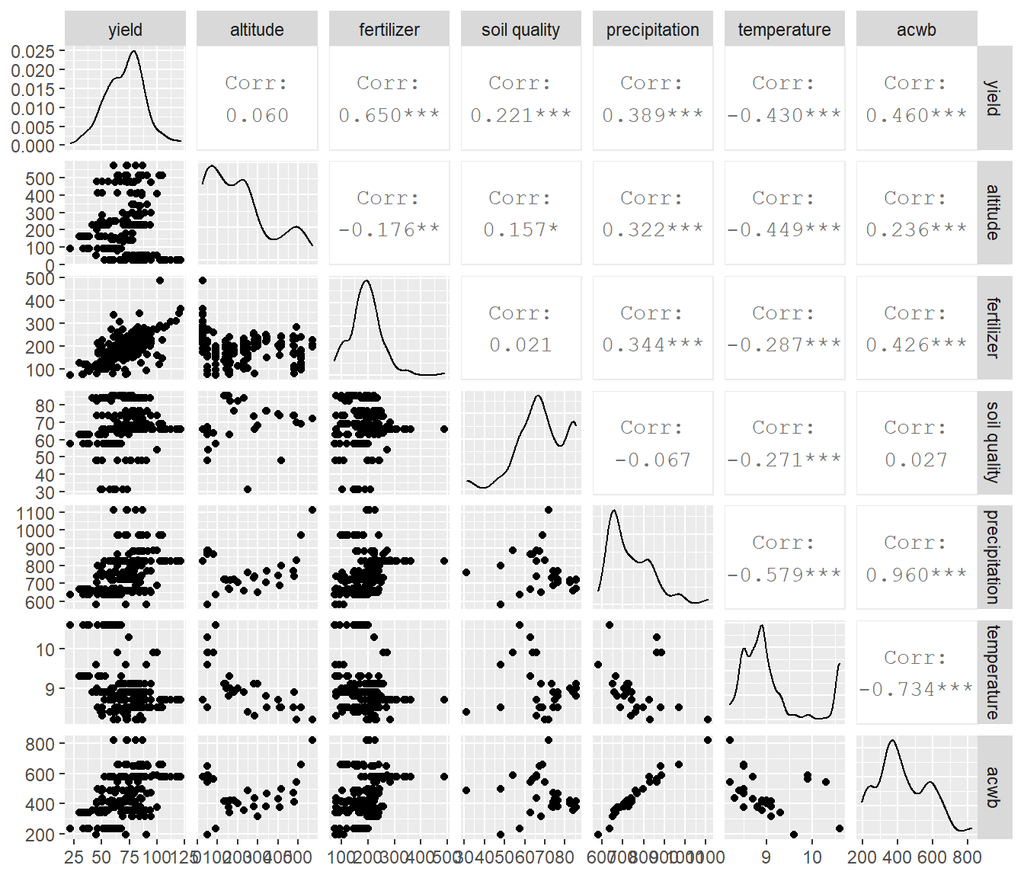

```r
#correlation plot
cor_plot <- GGally::ggpairs(model_data)

#save the plot
ggsave(plot= cor_plot,
       height = 8.1,
       width = 12,
       dpi = 1000,
       device = 'jpg',
       filename = 'Correlation Plot.jpg')

#plot the graph
print(cor_plot)
```

Linear Regression Assumption

- Normality of the y variable ..etc

To ensure we satisfy this requirement we do a density plot for wheat yield. please note ;

- Blue curve signifies the normal expected curve
- Grey curve indicates the actual distribution of wheat yield

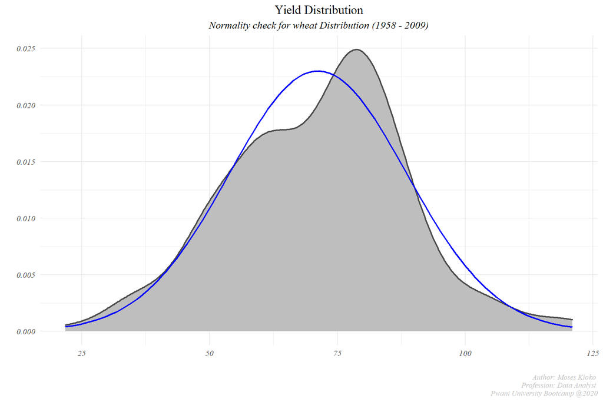

```r
density_plot <- model_data %>%
  ggplot(aes(yield))+
  geom_density(size =.8,color ='grey30',fill ='grey')+
  stat_function(fun=dnorm,color="blue",size =.8,args=list(mean=mean(model_data$yield),
                                  sd=sd(model_data$yield)))+
  theme_minimal()+
  labs(title = "Yield Distribution",
       subtitle = "Normality check for wheat Distribution (1958 - 2009)",
       y="",
       x="",
       caption = 'Author: Moses Kioko \n Profession: Data Analyst \n Pwani University Bootcamp @2020')+
  theme(legend.position = "none",
        legend.background = element_rect(color = "grey"),
        legend.title =  element_blank(),
        legend.text = element_text(family = "serif"),
        plot.title = element_text(hjust = 0.5,family = "serif"),
        axis.text = element_text(family = "serif", face = 'italic'),
        axis.title = element_text(family = "serif"),
        plot.subtitle = element_text(family = "serif",face = "italic",hjust = 0.5),
        plot.caption = element_text(size = 8,color = "grey",family = "serif",face = 'italic'))

#save the plot
ggsave(plot= density_plot,
       height = 8.1,
       width = 12,
       dpi = 1000,
       device = 'jpg',
       filename = 'Wheat Yield Distribution Graph.jpg')

#plot the graph
print(density_plot)
```

Running Linear/Multiple regression we use base R statistical function `lm()`. We run a regression model between the following variables **altitude, fertilizer, soil quality, precipitation, temperature**. Please note; We regress the **yield** variable against the rest of the variables to establish the relationship.

```r
#linear model
model = lm(yield ~ altitude+fertilizer+`soil quality`+precipitation+temperature,data=model_data)


#print out the summary of the model
summary(model)
```

```
##
## Call:
## lm(formula = yield ~ altitude + fertilizer + `soil quality` +
##     precipitation + temperature, data = model_data)
##
## Residuals:
##     Min      1Q  Median      3Q     Max
## -37.013  -6.431   0.698   6.203  46.487
##
## Coefficients:
##                 Estimate Std. Error t value Pr(>|t|)
## (Intercept)    37.218064  21.693593   1.716 0.087589 .
## altitude        0.004193   0.006297   0.666 0.506108
## fertilizer      0.171539   0.015967  10.744  < 2e-16 ***
## `soil quality`  0.239154   0.068828   3.475 0.000612 ***
## precipitation   0.018023   0.009874   1.825 0.069263 .
## temperature    -3.232906   1.571662  -2.057 0.040824 *
## ---
## Signif. codes:  0 '***' 0.001 '**' 0.01 '*' 0.05 '.' 0.1 ' ' 1
##
## Residual standard error: 12.18 on 228 degrees of freedom
## Multiple R-squared:  0.5165, Adjusted R-squared:  0.5059
## F-statistic: 48.71 on 5 and 228 DF,  p-value: < 2.2e-16
```

```r
#compute the best model
best_model = MASS::stepAIC(model,direction = "both")
```

```
## Start:  AIC=1176.01
## yield ~ altitude + fertilizer + `soil quality` + precipitation +
##     temperature
##
##                  Df Sum of Sq   RSS    AIC
## - altitude        1      65.8 33917 1174.5
## <none>                        33852 1176.0
## - precipitation   1     494.7 34346 1177.4
## - temperature     1     628.2 34480 1178.3
## - `soil quality`  1    1792.5 35644 1186.1
## - fertilizer      1   17137.2 50989 1269.9
##
## Step:  AIC=1174.47
## yield ~ fertilizer + `soil quality` + precipitation + temperature
##
##                  Df Sum of Sq   RSS    AIC
## <none>                        33917 1174.5
## + altitude        1      65.8 33852 1176.0
## - precipitation   1     590.2 34508 1176.5
## - temperature     1     891.8 34809 1178.5
## - `soil quality`  1    1855.0 35772 1184.9
## - fertilizer      1   19213.2 53131 1277.5
```

```r
#print out the summary of the model
summary(best_model)
```

```
##
## Call:
## lm(formula = yield ~ fertilizer + `soil quality` + precipitation +
##     temperature, data = model_data)
##
## Residuals:
##     Min      1Q  Median      3Q     Max
## -37.419  -6.712   0.551   6.261  45.887
##
## Coefficients:
##                 Estimate Std. Error t value Pr(>|t|)
## (Intercept)    41.049296  20.891451   1.965 0.050637 .
## fertilizer      0.167415   0.014699  11.390  < 2e-16 ***
## `soil quality`  0.242599   0.068550   3.539 0.000486 ***
## precipitation   0.019307   0.009672   1.996 0.047104 *
## temperature    -3.603036   1.468324  -2.454 0.014880 *
## ---
## Signif. codes:  0 '***' 0.001 '**' 0.01 '*' 0.05 '.' 0.1 ' ' 1
##
## Residual standard error: 12.17 on 229 degrees of freedom
## Multiple R-squared:  0.5155, Adjusted R-squared:  0.5071
## F-statistic: 60.92 on 4 and 229 DF,  p-value: < 2.2e-16
```

The final model equation $Yield = 41.049 + 0.167Ferterlizer + 0.243SoilQuality + 0.019Precipitation - 3.603Temperature$